# Intro to GIS / Mapping Visualization in R

Author

Aaron Kessler

Published

March 21, 2023

# Getting Geospatial Data Into R

There are two primary ways to get geodata into R: through a saved file you import, or though a package that will help download it directly from the web.

R can handle almost any type of GIS data, including shapefiles, geodatabases, geoJson, etc. We’ll look at the SF package, one of the best packages for doing importing and processing data.

What are “Simple Features” (SF)? The simple feature geodata format creates an object that behaves much like a dataframe in R, yet has spatial fields that contain the geographic information. This represents a big improvement over previous ways of handling geospatial data in R.

You may see older references online to the SP package, which is the former way of doing geospatial work. If you’re just starting out, you’re much better off focusing your efforts on the SF package from the get-go.

## Packages we’ll be using

There are a bunch of different R packages designed to work with geospatial data. We’ll touch on a few of them here, primarily the tmap package, but there are many more. Even ggplot2 itself now has functions to help handle sf objects!

Let’s look as some actual code and examples to get started…

# An Example: Plotting Points

We’ll use the tigris package to pull census boundary geo data into our session, for a state map of the US.

The tigris package is a wonderful resource for all kinds of boundary files several options for resolution - when using whole nation, 20m is usually better for individual states 5m may be preferable.

Ok, it’s nice I have this GIS data, how do I actually see anything? How do I map it out?

This is where you have many different options. But we’re going to start by using the powerful tmap package. Keep in mind tmap uses the + sign not the pipe, similar ggplot2.

Watch how simple it is to get something initial up to see:

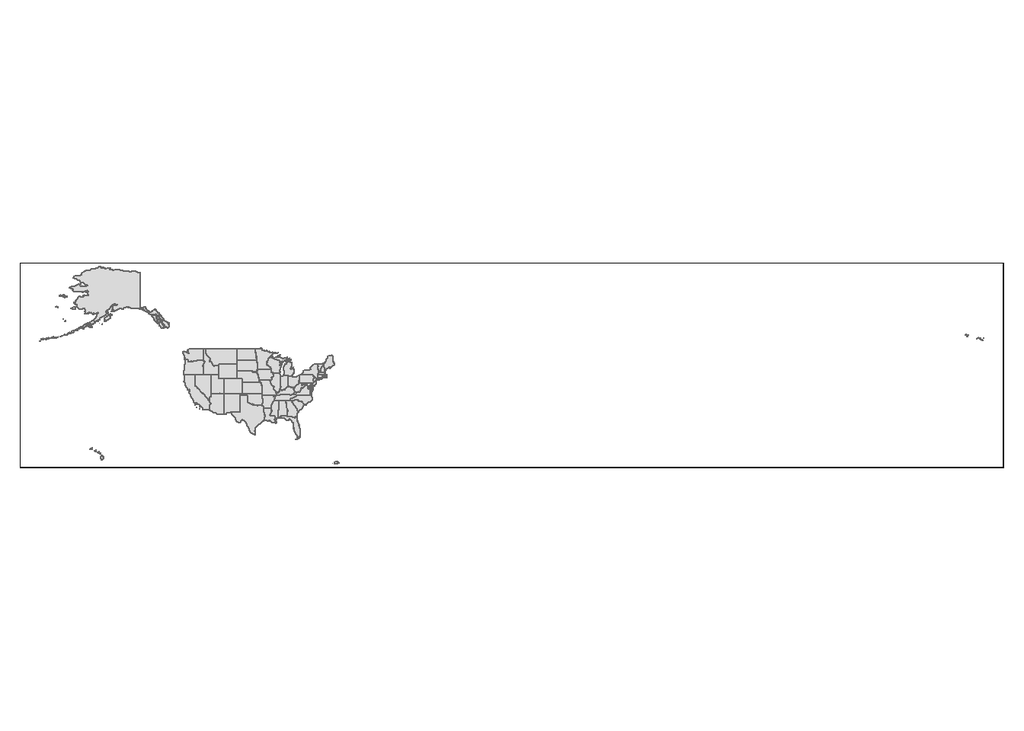

```r
tm_shape(states_geo) +
  tm_polygons()
```

What just happened there? Let’s discuss.

I said for now we’ll focus on the lower 48, how can we do that? Well you can filter sf objects much like you can a regular dataframe/tibble.

First, let’s start with just getting rid of U.S. territories, and just keep states, since this is something you’ll find yourself doing quite frequently.

Tigris also comes with a handle fips code table built in. All we have to do is reference it and can utilize its goodness.

```r
head(fips_codes)
```

```
  state state_code state_name county_code         county
1    AL         01    Alabama         001 Autauga County
2    AL         01    Alabama         003 Baldwin County
3    AL         01    Alabama         005 Barbour County
4    AL         01    Alabama         007    Bibb County
5    AL         01    Alabama         009  Blount County
6    AL         01    Alabama         011 Bullock County
```

This can be a great tool to help get down to just U.S. states and DC.

```r
vector_continentalus <- fips_codes %>%
  distinct(state) %>%
  filter(!state %in% c("AK", "HI", "PR", "AS", "GU", "MP", "UM", "VI")) %>%
  pull(state)
```

Now we’ll filter using our vector, must like we would a normal dataframe.

```r
states_geo <- states_geo %>%
  filter(STUSPS %in% vector_continentalus)
```

Did it work? Let’s see how many rows we have now.

```r
states_geo %>%
  nrow()
```

```
[1] 49
```

Let’s map things out now to see what we have.

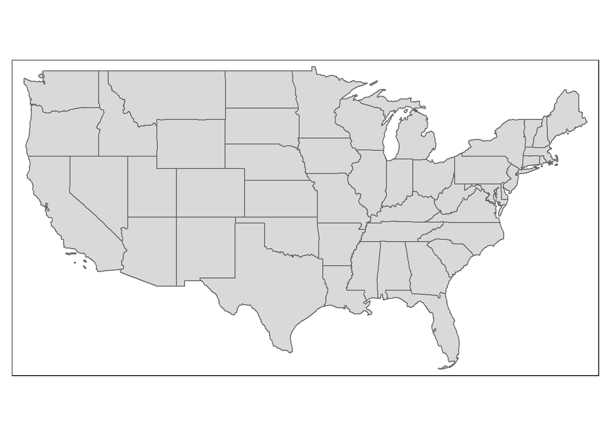

```r
tm_shape(states_geo) +
  tm_polygons()
```

Bingo.

tm_polygons also takes some other arguments, including assigning an ID.

One of the powerful arguments is to symbolize the data based on a certain column. All you have to do is feed in the name of the column you want to use to visualize by.

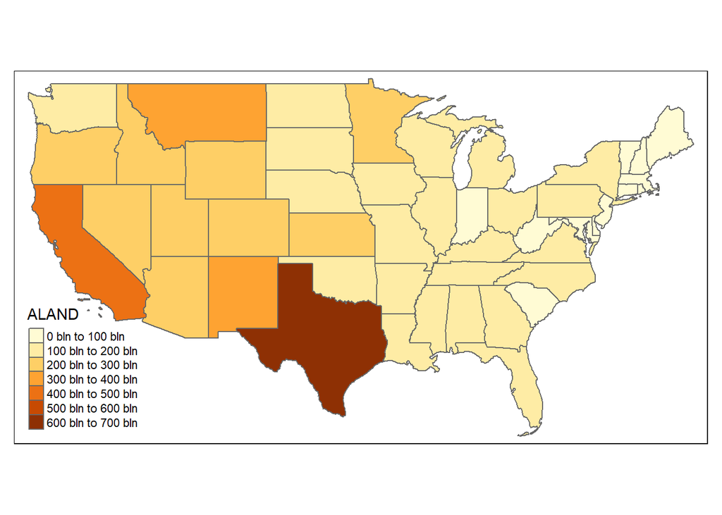

```r
tm_shape(states_geo) +
  tm_polygons("ALAND", id = "GEOID")#here we feed in the land area, ALAND
```

Generate it again but this time adding labels.

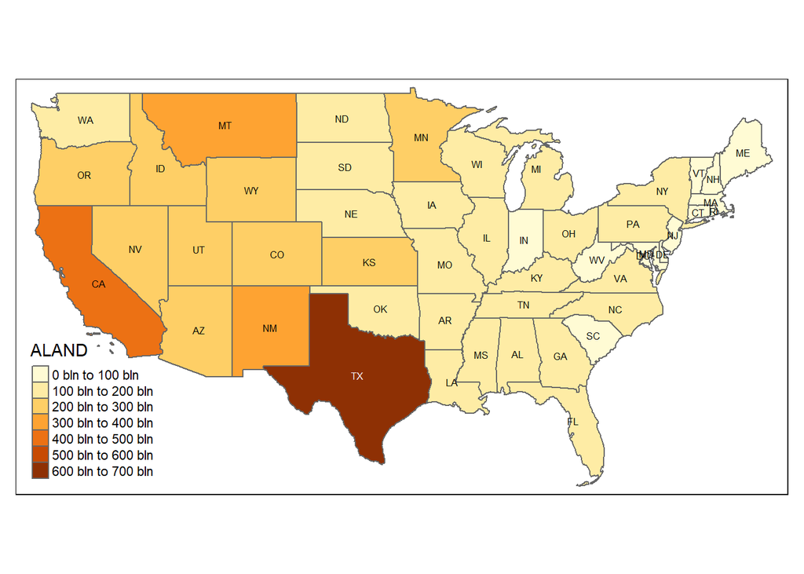

```r
tm_shape(states_geo) +
  tm_polygons("ALAND", id = "GEOID") +
  tm_text("STUSPS", size = .5) #this line adds the labels
```

```r
# there are numerous parameters and customizations you can do
```

At this point, let’s touch on two geospatial concepts:

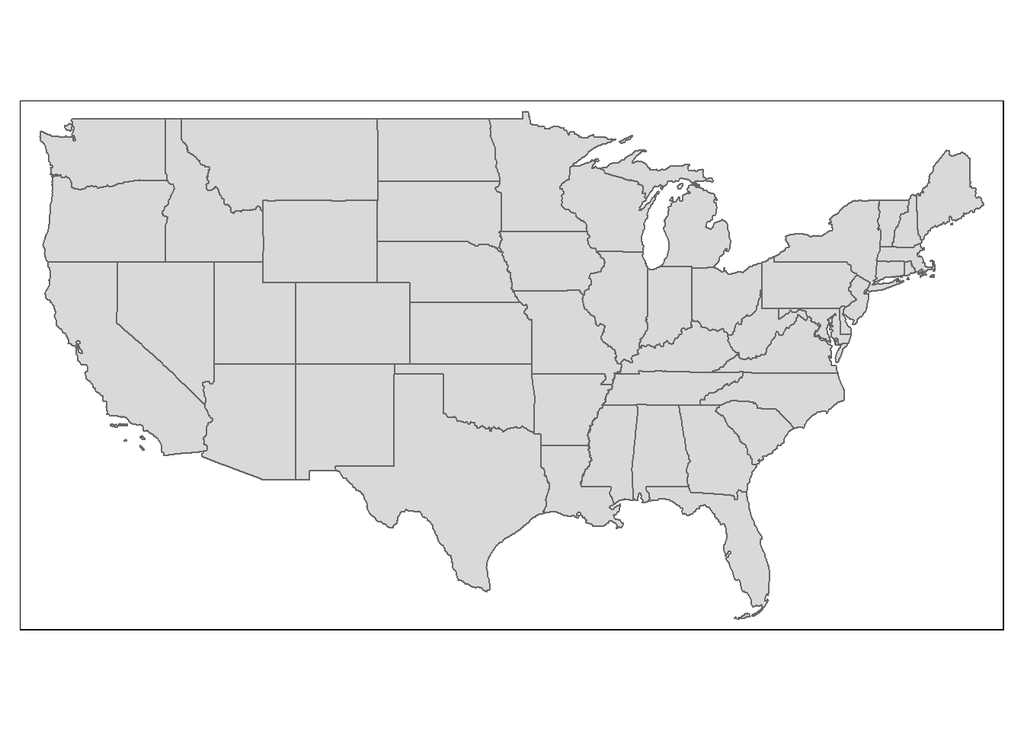

```r
# with cb
states_geo <- tigris::states(resolution = "20m", cb = TRUE) %>%
              filter(STUSPS %in% vector_continentalus,
                     !STUSPS %in% c("AK", "HI"))
tm_shape(states_geo) +
  tm_polygons()
```

```r
# without cb

# not run
# states_geo_nocb <- tigris::states(resolution = "20m") %>%
#   filter(STUSPS %in% vector_50anddc,
#          !STUSPS %in% c("AK", "HI"))
#
# tm_shape(states_geo_nocb) +
#   tm_polygons()
```

Notice what’s different? (Hint: look at MI and VA) Also it took a lot longer to plot the non-cb version, even with 20m resolution. Why is that?

For large sf objects where you’re more interested in visualizing, as opposed to spatial analysis based on distances etc, you can “simplify” the map object to decrease the size and boost rendering speed

```r
#not run
# states_geo_nocb_SIMPLIFIED <- rmapshaper::ms_simplify(states_geo_nocb, keep = 0.1)
```

```r
# let's see the difference
# tm_shape(states_geo_nocb_SIMPLIFIED) +
#   tm_polygons()
```

2. What is a Coordinate Reference System (CRS) and why is it important for mapping more than one element?
   - how can I check the CRS? How can I change it?
   - what’s the difference between planar and geodesic?
   - https://ihatecoordinatesystems.com/

the sf package’s st_crs() function returns the CRS of a simple feature object

```r
st_crs(states_geo)
```

```
Coordinate Reference System:
  User input: NAD83
  wkt:
GEOGCRS["NAD83",
    DATUM["North American Datum 1983",
        ELLIPSOID["GRS 1980",6378137,298.257222101,
            LENGTHUNIT["metre",1]]],
    PRIMEM["Greenwich",0,
        ANGLEUNIT["degree",0.0174532925199433]],
    CS[ellipsoidal,2],
        AXIS["latitude",north,
            ORDER[1],
            ANGLEUNIT["degree",0.0174532925199433]],
        AXIS["longitude",east,
            ORDER[2],
            ANGLEUNIT["degree",0.0174532925199433]],
    ID["EPSG",4269]]
```

This becomes very important when you want to layer different geo datasets, and when doing processing work such as spatial joins, or measuring distances and such. You want all the data to be using the same CRS, or you could wind up with distorted or incorrect results.

# Let’s add some cities as points

```r
# load a sample of US cities
cities <- read_csv(here("data", "cities_with_coordinates.csv"))
cities
```

```
# A tibble: 32 × 6
   city        state state_name    county_fips   lat   lon
   <chr>       <chr> <chr>         <chr>       <dbl> <dbl>
 1 Baltimore   MD    Maryland      24510        39.3 -76.6
 2 Buffalo     NY    New York      36029        42.9 -78.8
 3 McAllen     TX    Texas         48215        26.2 -98.2
 4 Tulsa       OK    Oklahoma      40143        36.1 -95.9
 5 Chattanooga TN    Tennessee     47065        35.1 -85.2
 6 Savannah    GA    Georgia       13051        32.0 -81.2
 7 Topeka      KS    Kansas        20177        39.0 -95.7
 8 Morgantown  WV    West Virginia 54061        39.6 -79.9
 9 Janesville  WI    Wisconsin     55105        42.7 -89.0
10 Bentonville AR    Arkansas      05007        36.4 -94.2
# … with 22 more rows
```

```r
# now we can create a geospatial object using the coordinates
# can can specify a crs
cities_geo <- st_as_sf(cities, coords = c("lon", "lat"), crs = 4269)
```

```r
st_crs(cities_geo)
```

```
Coordinate Reference System:
  User input: EPSG:4269
  wkt:
GEOGCRS["NAD83",
    DATUM["North American Datum 1983",
        ELLIPSOID["GRS 1980",6378137,298.257222101,
            LENGTHUNIT["metre",1]]],
    PRIMEM["Greenwich",0,
        ANGLEUNIT["degree",0.0174532925199433]],
    CS[ellipsoidal,2],
        AXIS["geodetic latitude (Lat)",north,
            ORDER[1],
            ANGLEUNIT["degree",0.0174532925199433]],
        AXIS["geodetic longitude (Lon)",east,
            ORDER[2],
            ANGLEUNIT["degree",0.0174532925199433]],
    USAGE[
        SCOPE["Geodesy."],
        AREA["North America - onshore and offshore: Canada - Alberta; British Columbia; Manitoba; New Brunswick; Newfoundland and Labrador; Northwest Territories; Nova Scotia; Nunavut; Ontario; Prince Edward Island; Quebec; Saskatchewan; Yukon. Puerto Rico. United States (USA) - Alabama; Alaska; Ari…
        BBOX[14.92,167.65,86.46,-47.74]],
    ID["EPSG",4269]]
```

```r
st_crs(states_geo)
```

```
Coordinate Reference System:
  User input: NAD83
  wkt:
GEOGCRS["NAD83",
    DATUM["North American Datum 1983",
        ELLIPSOID["GRS 1980",6378137,298.257222101,
            LENGTHUNIT["metre",1]]],
    PRIMEM["Greenwich",0,
        ANGLEUNIT["degree",0.0174532925199433]],
    CS[ellipsoidal,2],
        AXIS["latitude",north,
            ORDER[1],
            ANGLEUNIT["degree",0.0174532925199433]],
        AXIS["longitude",east,
            ORDER[2],
            ANGLEUNIT["degree",0.0174532925199433]],
    ID["EPSG",4269]]
```

looks like they’re the same crs - but are they exactly the same? sometimes helps to be extra sure that the text is identical we can change a CRS by using st_transform()

```r
cities_geo <- st_transform(cities_geo, st_crs(states_geo))
```

```r
# now let's look again
st_crs(cities_geo)
```

```
Coordinate Reference System:
  User input: NAD83
  wkt:
GEOGCRS["NAD83",
    DATUM["North American Datum 1983",
        ELLIPSOID["GRS 1980",6378137,298.257222101,
            LENGTHUNIT["metre",1]]],
    PRIMEM["Greenwich",0,
        ANGLEUNIT["degree",0.0174532925199433]],
    CS[ellipsoidal,2],
        AXIS["latitude",north,
            ORDER[1],
            ANGLEUNIT["degree",0.0174532925199433]],
        AXIS["longitude",east,
            ORDER[2],
            ANGLEUNIT["degree",0.0174532925199433]],
    ID["EPSG",4269]]
```

```r
st_crs(states_geo)
```

```
Coordinate Reference System:
  User input: NAD83
  wkt:
GEOGCRS["NAD83",
    DATUM["North American Datum 1983",
        ELLIPSOID["GRS 1980",6378137,298.257222101,
            LENGTHUNIT["metre",1]]],
    PRIMEM["Greenwich",0,
        ANGLEUNIT["degree",0.0174532925199433]],
    CS[ellipsoidal,2],
        AXIS["latitude",north,
            ORDER[1],
            ANGLEUNIT["degree",0.0174532925199433]],
        AXIS["longitude",east,
            ORDER[2],
            ANGLEUNIT["degree",0.0174532925199433]],
    ID["EPSG",4269]]
```

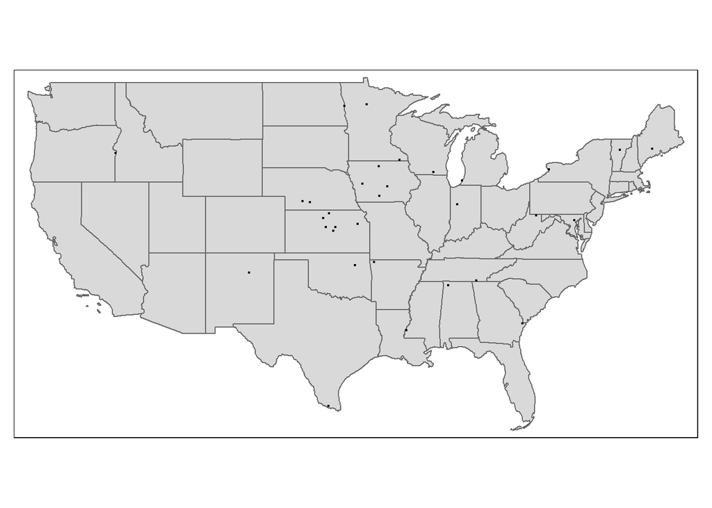

```r
# great, now let's map our new point layer on top of the base map
tm_shape(states_geo) + tm_polygons() +
  tm_shape(cities_geo) + tm_dots()
```

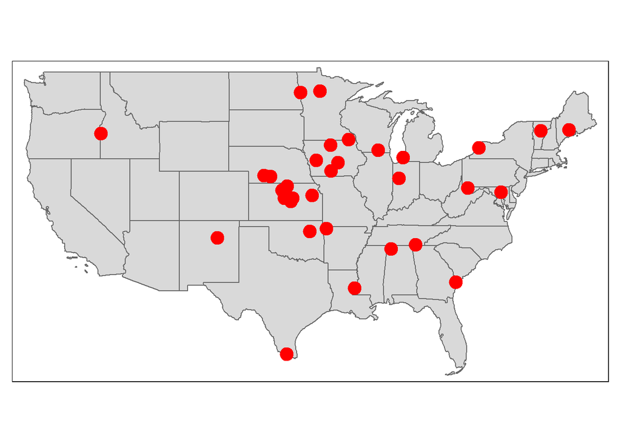

```r
# They're on there!
# Little hard to see though, let's fiddle with the size and color
tm_shape(states_geo) + tm_polygons() +
  tm_shape(cities_geo) + tm_dots(col = "red", size = 1)
```

```r
# we can actually save our tmap as its own object as well
mymap <- tm_shape(states_geo) + tm_polygons() +
  tm_shape(cities_geo) + tm_dots(col = "red", size = 0.1)

mymap
```

[output not shown]

```r
# We can either use the "export" button directly from the viewer to save as pdf...
# ...or do it using the following code:
tmap_save(mymap, here("mymap.pdf"))
```

```
Map saved to C:\Users\idguser\Documents\GITREPOS\github_kessler\smpa_rsession4_webpages_and_visuals\mymap.pdf
```

```
Size: 9.527778 by 5.125 inches
```

```r
# We can also save it as an RDS file - the entire map becomes the saved object
saveRDS(mymap, here("mymap.rds"))
```

```r
# why might we want to do this?
# one use case: if displaying in a complex map on an rmarkdown document / website,
# you don't have to compute it on the fly, can use the pre-processed result instead
map_to_include <- readRDS(here("mymap.rds"))
```

```r
map_to_include
```

Wish your tmap was interactive instead of static?

```r
# let's take a look
tmap_mode(mode = "view")
```

```
tmap mode set to interactive viewing
```

```r
# what's what happens
mymap
```

[interactive chart not shown]

you can also use the tmap_leaflet() function to convert to a leaflet object and further customize using the leaflet’s own methods

want to go back to static?

```r
tmap_mode(mode = "plot")
```

```
tmap mode set to plotting
```

```r
mymap
```

```r
# nice...
```

# Example: Chrolopeth maps of House Districts

```r
# We've done something with points, let's now look at a real-world chloropleth use case

# load dataset of district characteristics for pre-2018 election U.S. House districts
alldistricts <- readRDS(here("data", "alldistricts.rds"))

alldistricts
```

```
# A tibble: 435 × 15
   geoid state_…¹ house…² incum…³ race_…⁴ medin…⁵ medin…⁶ medage pct_r…⁷ pct_r…⁸
   <chr> <chr>    <chr>   <chr>   <chr>     <dbl> <chr>    <dbl>   <dbl> <chr>
 1 0101  Alabama  AL-01   R       <NA>      44824 BELOW     39.1    34.7 BELOW
 2 0102  Alabama  AL-02   R       <NA>      43173 BELOW     38.2    37.5 BELOW
 3 0103  Alabama  AL-03   R       <NA>      42953 BELOW     38.1    31.6 BELOW
 4 0104  Alabama  AL-04   R       <NA>      40267 BELOW     40.7    16.1 BELOW
 5 0105  Alabama  AL-05   R       <NA>      51830 BELOW     39.3    26.8 BELOW
 6 0106  Alabama  AL-06   R       <NA>      60706 ABOVE     38.8    23.0 BELOW
 7 0107  Alabama  AL-07   D       <NA>      33366 BELOW     35.8    68.0 ABOVE
 8 0200  Alaska   AK-00   R       <NA>      74444 ABOVE     33.6    38.0 BELOW
 9 0401  Arizona  AZ-01   D       lean d…   48583 BELOW     36.8    50.5 ABOVE
10 0402  Arizona  AZ-02   R       likely…   48125 BELOW     40.6    38.0 BELOW
# … with 425 more rows, 5 more variables: pct_ed_college_all <dbl>,
#   pct_ed_college_all_abovebelow_natl <chr>, prez_winner_2016 <chr>,
#   house_winner_2016 <chr>, prez_winner_2012 <chr>, and abbreviated variable
#   names ¹state_name, ²house_dist, ³incumbent_2018, ⁴race_rating_2018,
#   ⁵medincome, ⁶medincome_abovebelow_natl, ⁷pct_race_nonwhite,
#   ⁸pct_race_nonwhite_abovebelow_natl
```

```r
# Since above we used the tigris package to get our base map, this time let's see what's
# involved in loading a geospatial file you already have yourself and want to bring into R.
cd_geo <- st_read(here("data", "cb_2018_us_cd116_20m"))
head(cd_geo)
```

```
Simple feature collection with 6 features and 8 fields
Geometry type: MULTIPOLYGON
Dimension:     XY
Bounding box:  xmin: -122.512 ymin: 28.49422 xmax: -74.05162 ymax: 40.836
Geodetic CRS:  NAD83
  STATEFP CD116FP      AFFGEOID GEOID LSAD CDSESSN      ALAND    AWATER
1      34      10 5001600US3410  3410   C2     116  196397289  12474852
2      42      05 5001600US4205  4205   C2     116  548506604  26310378
3      06      12 5001600US0612  0612   C2     116  100885569 211661576
4      12      03 5001600US1203  1203   C2     116 9232593580 722972427
5      06      45 5001600US0645  0645   C2     116  856078764   5161857
6      12      07 5001600US1207  1207   C2     116 1017471375 110917454
                        geometry
1 MULTIPOLYGON (((-74.30292 4...
2 MULTIPOLYGON (((-75.5976 39...
3 MULTIPOLYGON (((-122.512 37...
4 MULTIPOLYGON (((-82.65855 2...
5 MULTIPOLYGON (((-117.8675 3...
6 MULTIPOLYGON (((-81.45916 2...
```

```r
# join our district dataset to its geography
# note that we can use dplyr's inner join here to join on the FIPS code (named geoid in the tables)
districtmap <- inner_join(cd_geo, alldistricts, by = c("GEOID" = "geoid"))
```

```r
# did it work?
glimpse(districtmap)# woohoo
```

```
Rows: 435
Columns: 23
$ STATEFP                            <chr> "34", "42", "06", "12", "06", "12",…
$ CD116FP                            <chr> "10", "05", "12", "03", "45", "07",…
$ AFFGEOID                           <chr> "5001600US3410", "5001600US4205", "…
$ GEOID                              <chr> "3410", "4205", "0612", "1203", "06…
$ LSAD                               <chr> "C2", "C2", "C2", "C2", "C2", "C2",…
$ CDSESSN                            <chr> "116", "116", "116", "116", "116", …
$ ALAND                              <dbl> 196397289, 548506604, 100885569, 92…
$ AWATER                             <dbl> 12474852, 26310378, 211661576, 7229…
$ state_name                         <chr> "New Jersey", "Pennsylvania", "Cali…
$ house_dist                         <chr> "NJ-10", "PA-05", "CA-12", "FL-03",…
$ incumbent_2018                     <chr> "D", "R", "D", "R", "R", "D", "D", …
$ race_rating_2018                   <chr> NA, "likely democratic", NA, NA, "t…
$ medincome                          <dbl> 48168.00, 71760.61, 88364.00, 45807…
$ medincome_abovebelow_natl          <chr> "BELOW", "ABOVE", "ABOVE", "BELOW",…
$ medage                             <dbl> 35.70000, 39.43435, 38.20000, 37.10…
$ pct_race_nonwhite                  <dbl> 80.02300, 35.85734, 56.53500, 30.98…
$ pct_race_nonwhite_abovebelow_natl  <chr> "ABOVE", "BELOW", "ABOVE", "BELOW",…
$ pct_ed_college_all                 <dbl> 27.55100, 35.48771, 56.32500, 26.36…
$ pct_ed_college_all_abovebelow_natl <chr> "BELOW", "ABOVE", "ABOVE", "BELOW",…
$ prez_winner_2016                   <chr> "D", "D", "D", "R", "D", "D", "D", …
$ house_winner_2016                  <chr> "D", NA, "D", "R", "R", "D", "D", "…
$ prez_winner_2012                   <chr> "D", "D", "D", "R", "R", "R", "D", …
$ geometry                           <MULTIPOLYGON [°]> MULTIPOLYGON (((-74.30…
```

```r
# remove AK and HI for expediency here again
districtmap <- districtmap %>%
  filter(state_name != "Alaska",
         state_name != "Hawaii")
```

```r
# Use TMAP to map it out

tmap_mode(mode = "plot")
```

```
tmap mode set to plotting
```

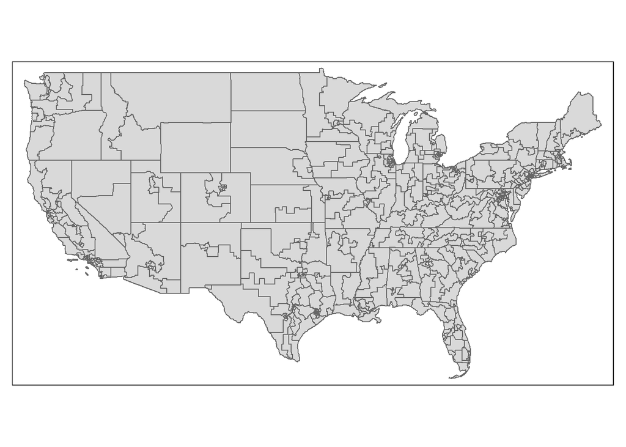

```r
tm_shape(districtmap) +
  tm_polygons(id = "house_dist")
```

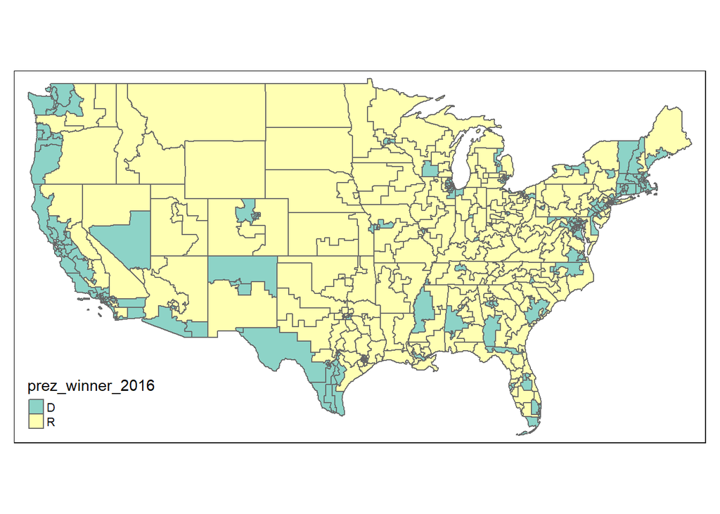

```r
# now let's actually do some analysis...
# which districts did Trump or Clinton carry in 2016?
# again you can customize color schemes, labels, etc... we'll just keep defaults for now.
tm_shape(districtmap) +
  tm_polygons("prez_winner_2016", id = "house_dist")
```

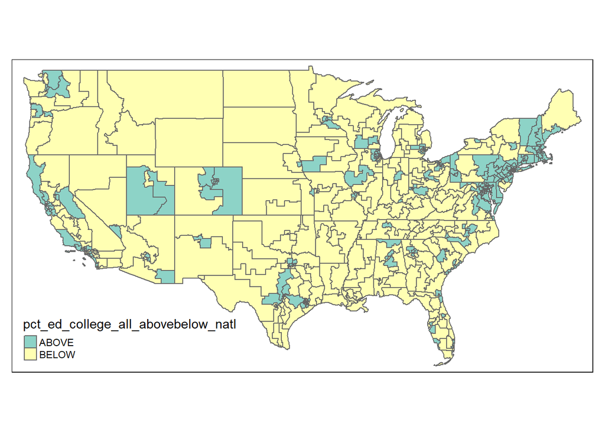

```r
# let's look at whether a district is above/below the national average for pct with a college degree?
tm_shape(districtmap) +
  tm_polygons("pct_ed_college_all_abovebelow_natl", id = "house_dist")
```

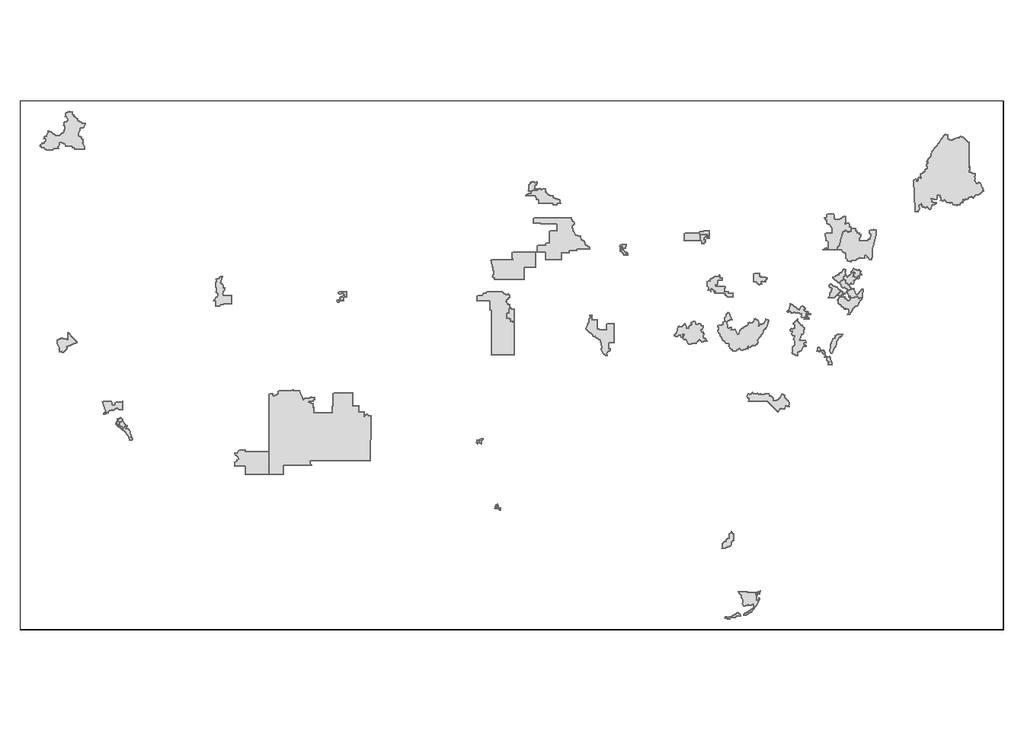

```r
# you can also filter our geospatial dataset to create subsets
# let's look at just GOP-held seats where the race was favoring the Dems or a tossup
rheld_demadvantage <- districtmap %>%
  filter(incumbent_2018 == "R",
         race_rating_2018 %in% c("likely democratic", "lean democratic", "tossup"))
# and then once again use tmap to display that
tm_shape(rheld_demadvantage) +
  tm_polygons(id = "house_dist")
```

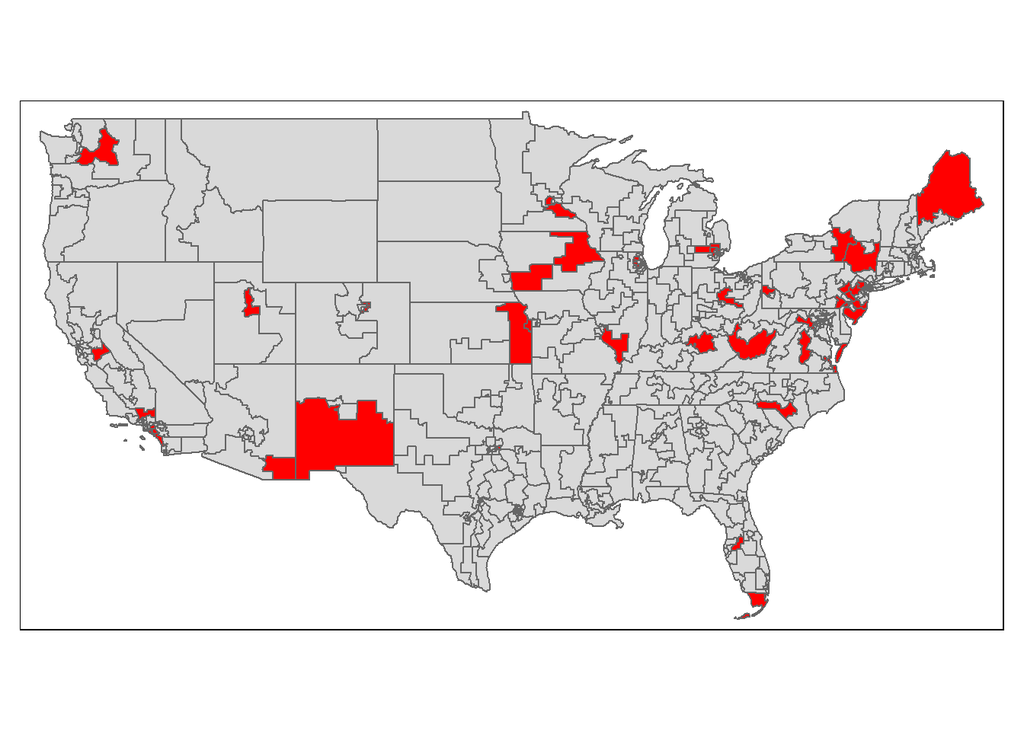

```r
# Of course what happens here - we don't have the rest of the CD map shown.
# So we can simply layer the base CD map underneath the filtered districts
tm_shape(districtmap) +
  tm_polygons(id = "house_dist") +
  tm_shape(rheld_demadvantage) +
  tm_polygons(col = "red", id = "house_dist")
```

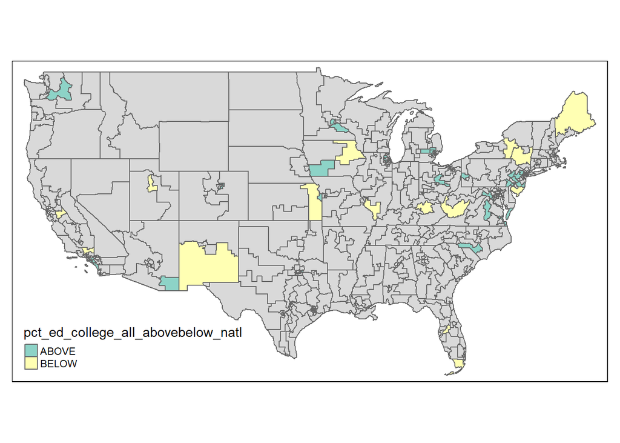

```r
# we can also symbolize the filtered districts by a variable if we want
tm_shape(districtmap) +
  tm_polygons(id = "house_dist") +
  tm_shape(rheld_demadvantage) +
  tm_polygons("pct_ed_college_all_abovebelow_natl", id = "house_dist")
```

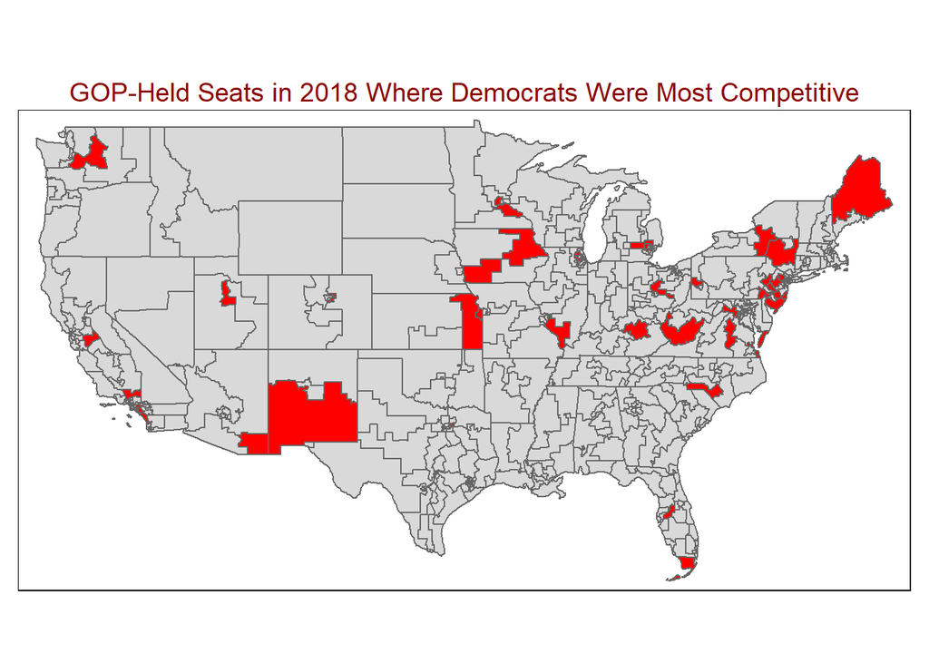

```r
# once we have something we want can save it as its own object
# here we'll add a title for the map, as well as a title for the legend
map_rheld_demadvantage_byeducation <- tm_shape(districtmap) +
  tm_polygons() +
  tm_shape(rheld_demadvantage) +
  tm_polygons(col = "red", id = "house_dist") +
  tm_layout(main.title = "GOP-Held Seats in 2018 Where Democrats Were Most Competitive",
            main.title.position = "center",
            main.title.color = "darkred",
            main.title.size = 1.2)

map_rheld_demadvantage_byeducation
```

```r
# now we can export it
tmap_save(map_rheld_demadvantage_byeducation, here("map_rheld_demadvantage_byeducation.pdf"))
```

```
Map saved to C:\Users\idguser\Documents\GITREPOS\github_kessler\smpa_rsession4_webpages_and_visuals\map_rheld_demadvantage_byeducation.pdf
```

```
Size: 9.527778 by 5.125 inches
```

# Spatial Joining

A spatial join is where instead of joining to tables based on matching a key field, you join two datasets based on their geospatial position in the world so to speak.

Spatial joining is a mainstay of GIS work, so let’s show a very quick example of one way to do it in R, using the data we’ve already seen. In this case, we had cities above mapped out. What if we wanted to know which congressional districts each city was in?

We have our cities:

```r
mymap
```

[output not shown]

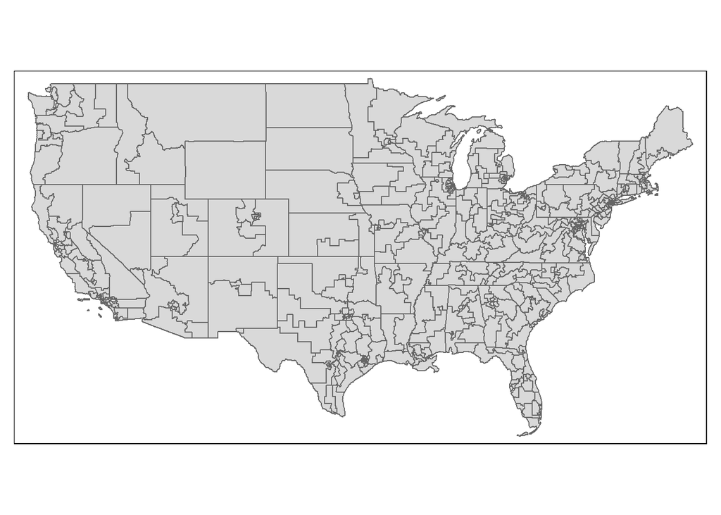

```r
# And we have our district boundaries:
tm_shape(districtmap) +
  tm_polygons()
```

Before we join, it’s always good practice to visually look at what you have. This will tell you if anything weird is happening you need to deal with first.

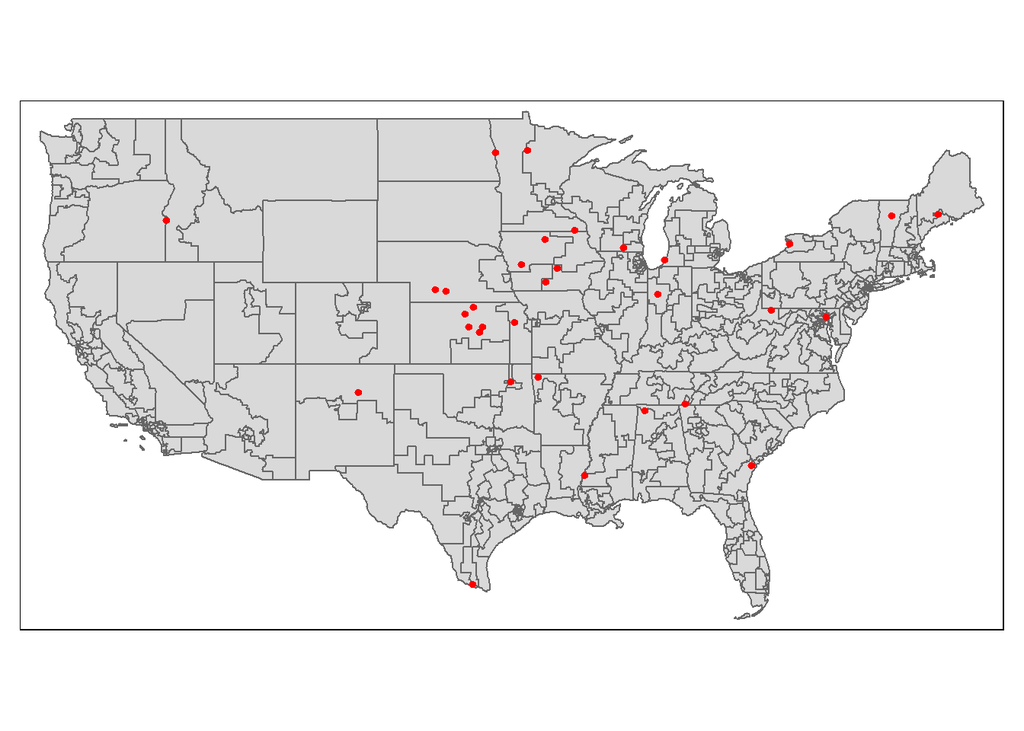

```r
tm_shape(districtmap) + tm_polygons() +
  tm_shape(cities_geo) + tm_dots(col = "red", size = 0.1)
```

Even though cities within districts may turn out ok as we are, let’s apply a planar CRS just to be sure.  
More information on the differences between coordinate systems here: https://tinyurl.com/t97h947v We’ll create two new R objects here to keep them distinct from the previous ones

```r
districtmap_forjoin <- st_transform(districtmap, 2163)
# now we'll assign cities to match what we just assigned for districts
cities_geo_forjoin <- st_transform(cities_geo, st_crs(districtmap_forjoin))
```

```r
st_crs(cities_geo_forjoin)
```

```
Coordinate Reference System:
  User input: EPSG:2163
  wkt:
PROJCRS["NAD27 / US National Atlas Equal Area",
    BASEGEOGCRS["NAD27",
        DATUM["North American Datum 1927",
            ELLIPSOID["Clarke 1866",6378206.4,294.978698213898,
                LENGTHUNIT["metre",1]]],
        PRIMEM["Greenwich",0,
            ANGLEUNIT["degree",0.0174532925199433]],
        ID["EPSG",4267]],
    CONVERSION["US National Atlas Equal Area",
        METHOD["Lambert Azimuthal Equal Area (Spherical)",
            ID["EPSG",1027]],
        PARAMETER["Latitude of natural origin",45,
            ANGLEUNIT["degree",0.0174532925199433],
            ID["EPSG",8801]],
        PARAMETER["Longitude of natural origin",-100,
            ANGLEUNIT["degree",0.0174532925199433],
            ID["EPSG",8802]],
        PARAMETER["False easting",0,
            LENGTHUNIT["metre",1],
            ID["EPSG",8806]],
        PARAMETER["False northing",0,
            LENGTHUNIT["metre",1],
            ID["EPSG",8807]]],
    CS[Cartesian,2],
        AXIS["easting (X)",east,
            ORDER[1],
            LENGTHUNIT["metre",1]],
        AXIS["northing (Y)",north,
            ORDER[2],
            LENGTHUNIT["metre",1]],
    USAGE[
        SCOPE["Statistical analysis."],
        AREA["United States (USA) - onshore and offshore."],
        BBOX[15.56,167.65,74.71,-65.69]],
    ID["EPSG",9311]]
```

```r
st_crs(districtmap_forjoin)
```

```
Coordinate Reference System:
  User input: EPSG:2163
  wkt:
PROJCRS["NAD27 / US National Atlas Equal Area",
    BASEGEOGCRS["NAD27",
        DATUM["North American Datum 1927",
            ELLIPSOID["Clarke 1866",6378206.4,294.978698213898,
                LENGTHUNIT["metre",1]]],
        PRIMEM["Greenwich",0,
            ANGLEUNIT["degree",0.0174532925199433]],
        ID["EPSG",4267]],
    CONVERSION["US National Atlas Equal Area",
        METHOD["Lambert Azimuthal Equal Area (Spherical)",
            ID["EPSG",1027]],
        PARAMETER["Latitude of natural origin",45,
            ANGLEUNIT["degree",0.0174532925199433],
            ID["EPSG",8801]],
        PARAMETER["Longitude of natural origin",-100,
            ANGLEUNIT["degree",0.0174532925199433],
            ID["EPSG",8802]],
        PARAMETER["False easting",0,
            LENGTHUNIT["metre",1],
            ID["EPSG",8806]],
        PARAMETER["False northing",0,
            LENGTHUNIT["metre",1],
            ID["EPSG",8807]]],
    CS[Cartesian,2],
        AXIS["easting (X)",east,
            ORDER[1],
            LENGTHUNIT["metre",1]],
        AXIS["northing (Y)",north,
            ORDER[2],
            LENGTHUNIT["metre",1]],
    USAGE[
        SCOPE["Statistical analysis."],
        AREA["United States (USA) - onshore and offshore."],
        BBOX[15.56,167.65,74.71,-65.69]],
    ID["EPSG",9311]]
```

```r
# Now let's do the join using sf's st_join() function
joined <- st_join(cities_geo_forjoin, districtmap_forjoin)
```

```r
joined # %>% View()
```

```
Simple feature collection with 32 features and 26 fields
Geometry type: POINT
Dimension:     XY
Bounding box:  xmin: -1348660 ymin: -2072249 xmax: 2344294 ymax: 371478.2
Projected CRS: NAD27 / US National Atlas Equal Area
# A tibble: 32 × 27
   city  state state…¹ count…²             geometry STATEFP CD116FP AFFGEOID
 * <chr> <chr> <chr>   <chr>            <POINT [m]> <chr>   <chr>   <chr>
 1 Balt… MD    Maryla… 24510    (1986364 -349916.9) 24      07      5001600US24…
 2 Buff… NY    New Yo… 36029    (1703715 -11057.69) 36      26      5001600US36…
 3 McAl… TX    Texas   48215    (177487.1 -2072249) 48      15      5001600US48…
 4 Tulsa OK    Oklaho… 40143   (369590.1 -975297.7) 40      01      5001600US40…
 5 Chat… TN    Tennes… 47065    (1341985 -984720.7) 47      03      5001600US47…
 6 Sava… GA    Georgia 13051     (1771470 -1242026) 13      01      5001600US13…
 7 Tope… KS    Kansas  20177     (372991.1 -652712) 20      02      5001600US20…
 8 Morg… WV    West V… 54061    (1702391 -388317.6) 54      01      5001600US54…
 9 Jane… WI    Wiscon… 55105   (897211.2 -196961.2) 55      01      5001600US55…
10 Bent… AR    Arkans… 05007   (518773.1 -941495.1) 05      03      5001600US05…
# … with 22 more rows, 19 more variables: GEOID <chr>, LSAD <chr>,
#   CDSESSN <chr>, ALAND <dbl>, AWATER <dbl>, state_name.y <chr>,
#   house_dist <chr>, incumbent_2018 <chr>, race_rating_2018 <chr>,
#   medincome <dbl>, medincome_abovebelow_natl <chr>, medage <dbl>,
#   pct_race_nonwhite <dbl>, pct_race_nonwhite_abovebelow_natl <chr>,
#   pct_ed_college_all <dbl>, pct_ed_college_all_abovebelow_natl <chr>,
#   prez_winner_2016 <chr>, house_winner_2016 <chr>, prez_winner_2012 <chr>, …
```

```r
# We can select just some relevant columns to simplify
joined %>%
  select(city, state, house_dist)
```

```
Simple feature collection with 32 features and 3 fields
Geometry type: POINT
Dimension:     XY
Bounding box:  xmin: -1348660 ymin: -2072249 xmax: 2344294 ymax: 371478.2
Projected CRS: NAD27 / US National Atlas Equal Area
# A tibble: 32 × 4
   city        state house_dist             geometry
   <chr>       <chr> <chr>               <POINT [m]>
 1 Baltimore   MD    MD-07       (1986364 -349916.9)
 2 Buffalo     NY    NY-26       (1703715 -11057.69)
 3 McAllen     TX    TX-15       (177487.1 -2072249)
 4 Tulsa       OK    OK-01      (369590.1 -975297.7)
 5 Chattanooga TN    TN-03       (1341985 -984720.7)
 6 Savannah    GA    GA-01        (1771470 -1242026)
 7 Topeka      KS    KS-02        (372991.1 -652712)
 8 Morgantown  WV    WV-01       (1702391 -388317.6)
 9 Janesville  WI    WI-01      (897211.2 -196961.2)
10 Bentonville AR    AR-03      (518773.1 -941495.1)
# … with 22 more rows
```

```r
# Cool, that's better. Though notice the geometry always travels with it.
# What if you wanted to just have a table as the result, without the geometry?
# The sf package to the rescue again...
matched_table <- joined %>%
  select(city, state, house_dist) %>%
  st_set_geometry(NULL)

matched_table
```

```
# A tibble: 32 × 3
   city        state house_dist
 * <chr>       <chr> <chr>
 1 Baltimore   MD    MD-07
 2 Buffalo     NY    NY-26
 3 McAllen     TX    TX-15
 4 Tulsa       OK    OK-01
 5 Chattanooga TN    TN-03
 6 Savannah    GA    GA-01
 7 Topeka      KS    KS-02
 8 Morgantown  WV    WV-01
 9 Janesville  WI    WI-01
10 Bentonville AR    AR-03
# … with 22 more rows
```

# Automating Repetitive GIS Work

One area where R can be especially helpful is when you need to do a bunch of variations of the same thing. Let’s take a quick look at an example.

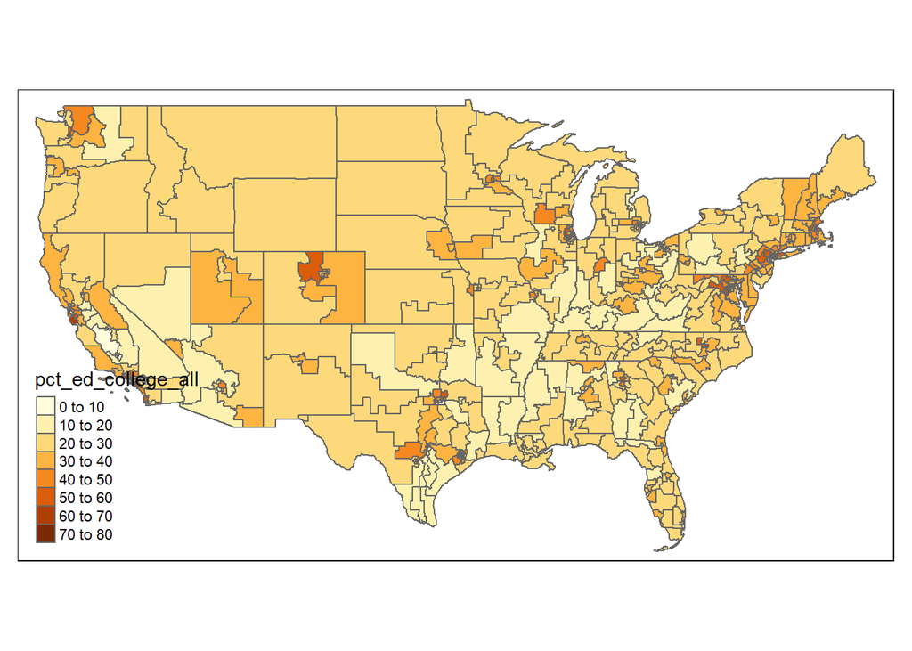

```r
# We'll use a measure from our congressional district data from above to examine pct with college degrees
tm_shape(districtmap) +
  tm_polygons("pct_ed_college_all", id = "GEOID")
```

Cool, so for the the whole country, that was easy enough. But what about if our need was to have maps for EVERY STATE. A separate map for each showing the same. Perhaps to go with state-specific pages on our website etc.

First, let’s solve for one state. How could we do that…

```r
# Since the state abbreviation isn't in our current districtmap object, let's get it in there
fips_statelookup <- fips_codes %>%
  as_tibble() %>%
  select(state, state_code) %>%
  distinct()

fips_statelookup
```

```
# A tibble: 57 × 2
   state state_code
   <chr> <chr>
 1 AL    01
 2 AK    02
 3 AZ    04
 4 AR    05
 5 CA    06
 6 CO    08
 7 CT    09
 8 DE    10
 9 DC    11
10 FL    12
# … with 47 more rows
```

```r
districtmap <- inner_join(districtmap, fips_statelookup, by = c("STATEFP" = "state_code"))
```

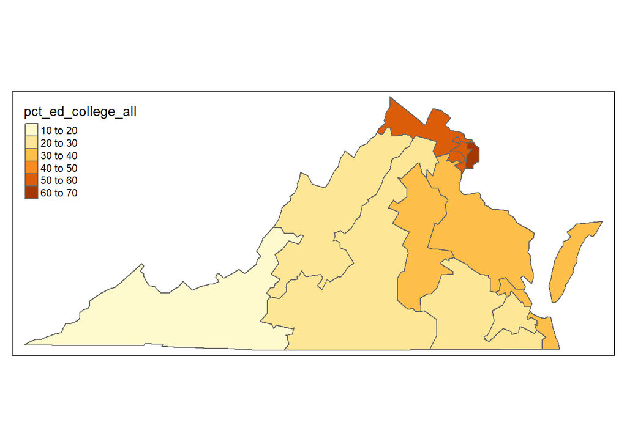

```r
# create slice of just one state
cd_onestate <- districtmap %>%
  filter(state == "VA")
#let's see what we've got
tm_shape(cd_onestate) +
  tm_polygons("pct_ed_college_all", id = "GEOID")
```

Let’s make a FUNCTION now to do this for a state We’ll use the state abbreviation to feed into it

```r
make_state_map <- function(stateabbr){
#choose state
  cd_onestate <- districtmap %>%
    filter(state == stateabbr)
# create cd map for the state
  mymap_test <-  tm_shape(cd_onestate) +
    tm_polygons("pct_ed_college_all", id = "GEOID") +
    tm_text("CD116FP", size = .5)
#export file to pdf
  filename <- paste0("stateoutputs/districtmap_", stateabbr, ".pdf")
  print(filename)
  tmap_save(mymap_test, filename)
}
```

```r
# try for just one state
make_state_map("VA")
```

```
[1] "stateoutputs/districtmap_VA.pdf"
```

```
Map saved to C:\Users\idguser\Documents\GITREPOS\github_kessler\smpa_rsession4_webpages_and_visuals\stateoutputs\districtmap_VA.pdf
```

```
Size: 10.54167 by 4.638889 inches
```

```r
# let's take a look at the generated pdf file. Did it work?
```

```r
# Now that we know it works for one, we can do it for ALL states in a list we determine.
# Let's create a vector of all the states in our original map
vector_targetstates <- districtmap %>%
  st_set_geometry(NULL) %>%
  count(state) %>%
  pull(state)
```

```r
# Then we'll use that to feed into our new function to loop through everything at once.
# We'll iterate through them all using purrr's walk() function
walk(vector_targetstates, make_state_map)
```

```
[1] "stateoutputs/districtmap_AL.pdf"
```

```
Map saved to C:\Users\idguser\Documents\GITREPOS\github_kessler\smpa_rsession4_webpages_and_visuals\stateoutputs\districtmap_AL.pdf
```

```
Size: 5.555556 by 8.805556 inches
```

```
[1] "stateoutputs/districtmap_AR.pdf"
```

```
Map saved to C:\Users\idguser\Documents\GITREPOS\github_kessler\smpa_rsession4_webpages_and_visuals\stateoutputs\districtmap_AR.pdf
```

```
Size: 7.555556 by 6.472222 inches
```

```
[1] "stateoutputs/districtmap_AZ.pdf"
```

```
Map saved to C:\Users\idguser\Documents\GITREPOS\github_kessler\smpa_rsession4_webpages_and_visuals\stateoutputs\districtmap_AZ.pdf
```

```
Size: 6.416667 by 7.625 inches
```

```
[1] "stateoutputs/districtmap_CA.pdf"
```

```
Map saved to C:\Users\idguser\Documents\GITREPOS\github_kessler\smpa_rsession4_webpages_and_visuals\stateoutputs\districtmap_CA.pdf
```

```
Size: 6.5 by 7.527778 inches
```

```
[1] "stateoutputs/districtmap_CO.pdf"
```

```
Map saved to C:\Users\idguser\Documents\GITREPOS\github_kessler\smpa_rsession4_webpages_and_visuals\stateoutputs\districtmap_CO.pdf
```

```
Size: 8.152778 by 6 inches
```

```
[1] "stateoutputs/districtmap_CT.pdf"
```

```
Map saved to C:\Users\idguser\Documents\GITREPOS\github_kessler\smpa_rsession4_webpages_and_visuals\stateoutputs\districtmap_CT.pdf
```

```
Size: 8.166667 by 5.986111 inches
```

```
[1] "stateoutputs/districtmap_DE.pdf"
```

```
Map saved to C:\Users\idguser\Documents\GITREPOS\github_kessler\smpa_rsession4_webpages_and_visuals\stateoutputs\districtmap_DE.pdf
```

```
Size: 4.486111 by 10.88889 inches
```

```
[1] "stateoutputs/districtmap_FL.pdf"
```

```
Map saved to C:\Users\idguser\Documents\GITREPOS\github_kessler\smpa_rsession4_webpages_and_visuals\stateoutputs\districtmap_FL.pdf
```

```
Size: 7.111111 by 6.875 inches
```

```
[1] "stateoutputs/districtmap_GA.pdf"
```

```
Map saved to C:\Users\idguser\Documents\GITREPOS\github_kessler\smpa_rsession4_webpages_and_visuals\stateoutputs\districtmap_GA.pdf
```

```
Size: 6.5 by 7.527778 inches
```

```
[1] "stateoutputs/districtmap_IA.pdf"
```

```
Map saved to C:\Users\idguser\Documents\GITREPOS\github_kessler\smpa_rsession4_webpages_and_visuals\stateoutputs\districtmap_IA.pdf
```

```
Size: 8.694444 by 5.625 inches
```

```
[1] "stateoutputs/districtmap_ID.pdf"
```

```
Map saved to C:\Users\idguser\Documents\GITREPOS\github_kessler\smpa_rsession4_webpages_and_visuals\stateoutputs\districtmap_ID.pdf
```

```
Size: 5.5 by 8.888889 inches
```

```
[1] "stateoutputs/districtmap_IL.pdf"
```

```
Map saved to C:\Users\idguser\Documents\GITREPOS\github_kessler\smpa_rsession4_webpages_and_visuals\stateoutputs\districtmap_IL.pdf
```

```
Size: 5.222222 by 9.361111 inches
```

```
[1] "stateoutputs/districtmap_IN.pdf"
```

```
Map saved to C:\Users\idguser\Documents\GITREPOS\github_kessler\smpa_rsession4_webpages_and_visuals\stateoutputs\districtmap_IN.pdf
```

```
Size: 5.555556 by 8.805556 inches
```

```
[1] "stateoutputs/districtmap_KS.pdf"
```

```
Map saved to C:\Users\idguser\Documents\GITREPOS\github_kessler\smpa_rsession4_webpages_and_visuals\stateoutputs\districtmap_KS.pdf
```

```
Size: 9.736111 by 5.013889 inches
```

```
[1] "stateoutputs/districtmap_KY.pdf"
```

```
Map saved to C:\Users\idguser\Documents\GITREPOS\github_kessler\smpa_rsession4_webpages_and_visuals\stateoutputs\districtmap_KY.pdf
```

```
Size: 10.52778 by 4.638889 inches
```

```
[1] "stateoutputs/districtmap_LA.pdf"
```

```
Map saved to C:\Users\idguser\Documents\GITREPOS\github_kessler\smpa_rsession4_webpages_and_visuals\stateoutputs\districtmap_LA.pdf
```

```
Size: 7.180556 by 6.805556 inches
```

```
[1] "stateoutputs/districtmap_MA.pdf"
```

```
Map saved to C:\Users\idguser\Documents\GITREPOS\github_kessler\smpa_rsession4_webpages_and_visuals\stateoutputs\districtmap_MA.pdf
```

```
Size: 8.888889 by 5.5 inches
```

```
[1] "stateoutputs/districtmap_MD.pdf"
```

```
Map saved to C:\Users\idguser\Documents\GITREPOS\github_kessler\smpa_rsession4_webpages_and_visuals\stateoutputs\districtmap_MD.pdf
```

```
Size: 9.680556 by 5.055556 inches
```

```
[1] "stateoutputs/districtmap_ME.pdf"
```

```
Map saved to C:\Users\idguser\Documents\GITREPOS\github_kessler\smpa_rsession4_webpages_and_visuals\stateoutputs\districtmap_ME.pdf
```

```
Size: 5.680556 by 8.597222 inches
```

```
[1] "stateoutputs/districtmap_MI.pdf"
```

```
Map saved to C:\Users\idguser\Documents\GITREPOS\github_kessler\smpa_rsession4_webpages_and_visuals\stateoutputs\districtmap_MI.pdf
```

```
Size: 6.513889 by 7.5 inches
```

```
[1] "stateoutputs/districtmap_MN.pdf"
```

```
Map saved to C:\Users\idguser\Documents\GITREPOS\github_kessler\smpa_rsession4_webpages_and_visuals\stateoutputs\districtmap_MN.pdf
```

```
Size: 6.652778 by 7.347222 inches
```

```
[1] "stateoutputs/districtmap_MO.pdf"
```

```
Map saved to C:\Users\idguser\Documents\GITREPOS\github_kessler\smpa_rsession4_webpages_and_visuals\stateoutputs\districtmap_MO.pdf
```

```
Size: 7.444444 by 6.569444 inches
```

```
[1] "stateoutputs/districtmap_MS.pdf"
```

```
Map saved to C:\Users\idguser\Documents\GITREPOS\github_kessler\smpa_rsession4_webpages_and_visuals\stateoutputs\districtmap_MS.pdf
```

```
Size: 5.513889 by 8.875 inches
```

```
[1] "stateoutputs/districtmap_MT.pdf"
```

```
Map saved to C:\Users\idguser\Documents\GITREPOS\github_kessler\smpa_rsession4_webpages_and_visuals\stateoutputs\districtmap_MT.pdf
```

```
Size: 9.333333 by 5.236111 inches
```

```
[1] "stateoutputs/districtmap_NC.pdf"
```

```
Map saved to C:\Users\idguser\Documents\GITREPOS\github_kessler\smpa_rsession4_webpages_and_visuals\stateoutputs\districtmap_NC.pdf
```

```
Size: 11.375 by 4.291667 inches
```

```
[1] "stateoutputs/districtmap_ND.pdf"
```

```
Map saved to C:\Users\idguser\Documents\GITREPOS\github_kessler\smpa_rsession4_webpages_and_visuals\stateoutputs\districtmap_ND.pdf
```

```
Size: 8.986111 by 5.444444 inches
```

```
[1] "stateoutputs/districtmap_NE.pdf"
```

```
Map saved to C:\Users\idguser\Documents\GITREPOS\github_kessler\smpa_rsession4_webpages_and_visuals\stateoutputs\districtmap_NE.pdf
```

```
Size: 10.33333 by 4.736111 inches
```

```
[1] "stateoutputs/districtmap_NH.pdf"
```

```
Map saved to C:\Users\idguser\Documents\GITREPOS\github_kessler\smpa_rsession4_webpages_and_visuals\stateoutputs\districtmap_NH.pdf
```

```
Size: 5 by 9.791667 inches
```

```
[1] "stateoutputs/districtmap_NJ.pdf"
```

```
Map saved to C:\Users\idguser\Documents\GITREPOS\github_kessler\smpa_rsession4_webpages_and_visuals\stateoutputs\districtmap_NJ.pdf
```

```
Size: 5.055556 by 9.666667 inches
```

```
[1] "stateoutputs/districtmap_NM.pdf"
```

```
Map saved to C:\Users\idguser\Documents\GITREPOS\github_kessler\smpa_rsession4_webpages_and_visuals\stateoutputs\districtmap_NM.pdf
```

```
Size: 6.569444 by 7.444444 inches
```

```
[1] "stateoutputs/districtmap_NV.pdf"
```

```
Map saved to C:\Users\idguser\Documents\GITREPOS\github_kessler\smpa_rsession4_webpages_and_visuals\stateoutputs\districtmap_NV.pdf
```

```
Size: 5.708333 by 8.569444 inches
```

```
[1] "stateoutputs/districtmap_NY.pdf"
```

```
Map saved to C:\Users\idguser\Documents\GITREPOS\github_kessler\smpa_rsession4_webpages_and_visuals\stateoutputs\districtmap_NY.pdf
```

```
Size: 7.930556 by 6.166667 inches
```

```
[1] "stateoutputs/districtmap_OH.pdf"
```

```
Map saved to C:\Users\idguser\Documents\GITREPOS\github_kessler\smpa_rsession4_webpages_and_visuals\stateoutputs\districtmap_OH.pdf
```

```
Size: 6.708333 by 7.291667 inches
```

```
[1] "stateoutputs/districtmap_OK.pdf"
```

```
Map saved to C:\Users\idguser\Documents\GITREPOS\github_kessler\smpa_rsession4_webpages_and_visuals\stateoutputs\districtmap_OK.pdf
```

```
Size: 10.06944 by 4.861111 inches
```

```
[1] "stateoutputs/districtmap_OR.pdf"
```

```
Map saved to C:\Users\idguser\Documents\GITREPOS\github_kessler\smpa_rsession4_webpages_and_visuals\stateoutputs\districtmap_OR.pdf
```

```
Size: 8.152778 by 6 inches
```

```
[1] "stateoutputs/districtmap_PA.pdf"
```

```
Map saved to C:\Users\idguser\Documents\GITREPOS\github_kessler\smpa_rsession4_webpages_and_visuals\stateoutputs\districtmap_PA.pdf
```

```
Size: 9.180556 by 5.319444 inches
```

```
[1] "stateoutputs/districtmap_RI.pdf"
```

```
Map saved to C:\Users\idguser\Documents\GITREPOS\github_kessler\smpa_rsession4_webpages_and_visuals\stateoutputs\districtmap_RI.pdf
```

```
Size: 5.583333 by 8.763889 inches
```

```
[1] "stateoutputs/districtmap_SC.pdf"
```

```
Map saved to C:\Users\idguser\Documents\GITREPOS\github_kessler\smpa_rsession4_webpages_and_visuals\stateoutputs\districtmap_SC.pdf
```

```
Size: 7.861111 by 6.222222 inches
```

```
[1] "stateoutputs/districtmap_SD.pdf"
```

```
Map saved to C:\Users\idguser\Documents\GITREPOS\github_kessler\smpa_rsession4_webpages_and_visuals\stateoutputs\districtmap_SD.pdf
```

```
Size: 8.777778 by 5.569444 inches
```

```
[1] "stateoutputs/districtmap_TN.pdf"
```

```
Map saved to C:\Users\idguser\Documents\GITREPOS\github_kessler\smpa_rsession4_webpages_and_visuals\stateoutputs\districtmap_TN.pdf
```

```
Size: 14.23611 by 3.430556 inches
```

```
[1] "stateoutputs/districtmap_TX.pdf"
```

```
Map saved to C:\Users\idguser\Documents\GITREPOS\github_kessler\smpa_rsession4_webpages_and_visuals\stateoutputs\districtmap_TX.pdf
```

```
Size: 7.166667 by 6.819444 inches
```

```
[1] "stateoutputs/districtmap_UT.pdf"
```

```
Map saved to C:\Users\idguser\Documents\GITREPOS\github_kessler\smpa_rsession4_webpages_and_visuals\stateoutputs\districtmap_UT.pdf
```

```
Size: 6.152778 by 7.958333 inches
```

```
[1] "stateoutputs/districtmap_VA.pdf"
```

```
Map saved to C:\Users\idguser\Documents\GITREPOS\github_kessler\smpa_rsession4_webpages_and_visuals\stateoutputs\districtmap_VA.pdf
```

```
Size: 10.54167 by 4.638889 inches
```

```
[1] "stateoutputs/districtmap_VT.pdf"
```

```
Map saved to C:\Users\idguser\Documents\GITREPOS\github_kessler\smpa_rsession4_webpages_and_visuals\stateoutputs\districtmap_VT.pdf
```

```
Size: 5.472222 by 8.944444 inches
```

```
[1] "stateoutputs/districtmap_WA.pdf"
```

```
Map saved to C:\Users\idguser\Documents\GITREPOS\github_kessler\smpa_rsession4_webpages_and_visuals\stateoutputs\districtmap_WA.pdf
```

```
Size: 8.652778 by 5.652778 inches
```

```
[1] "stateoutputs/districtmap_WI.pdf"
```

```
Map saved to C:\Users\idguser\Documents\GITREPOS\github_kessler\smpa_rsession4_webpages_and_visuals\stateoutputs\districtmap_WI.pdf
```

```
Size: 6.805556 by 7.194444 inches
```

```
[1] "stateoutputs/districtmap_WV.pdf"
```

```
Map saved to C:\Users\idguser\Documents\GITREPOS\github_kessler\smpa_rsession4_webpages_and_visuals\stateoutputs\districtmap_WV.pdf
```

```
Size: 7.375 by 6.638889 inches
```

```
[1] "stateoutputs/districtmap_WY.pdf"
```

```
Map saved to C:\Users\idguser\Documents\GITREPOS\github_kessler\smpa_rsession4_webpages_and_visuals\stateoutputs\districtmap_WY.pdf
```

```
Size: 7.902778 by 6.180556 inches
```

What on earth are functions and how do they work? We’ll talk about that next time…